# Statistical inference with the GSS data

## Setup

### Load packages

```r
library(ggplot2)
library(dplyr)
library(statsr)
library(shiny)
```

### Load data

```r
load("gss.Rdata")
```

## Part 1: Data

**Source**:

As per the GSS documentation [website](http://gss.norc.org/get-documentation), information on **sampling design and weighting** is recorded in the GSS Codebook - [Appendix A](http://gss.norc.org/documents/codebook/GSS_Codebook_AppendixA.pdf).

**A summary of the appendix**:

The GSS sampling method has been evolving over time in its history. Before 1974, fund support was only given for a modified probability sample. Then, the NSF renewal grant, awarded for the 1975-1977 surveys, provided funds for a full probability sample design, so the 1975 and 1976 studies were conducted with a transitional sample design, viz., one-half full probability and one-half block quota. According to the appendix, block quota is a multi-stage area probability sample to the block or segment level. The cost of quota samples is much less than a fully random sample of the same size, but it might also introduce sample biases due to not-at-homes. Such biases are said to be relatively small, but there is still considerable controversy and ambiguity about block quota samples. Since 1977, the GSS switched to a full probability sample for the 1977+ surveys, so the transitional sample design is over. However, we should also notice that the GSS did not sample non-English speakers until 2006. There is a bias.

**Conclusions**:

1. Data collected before 1974 can not be considered random samples, results based on such data can not be generalized.
2. In 1975 and 1976, only half of the sample data is fully random, the other half of block quota data is controversial. Since most textbooks are based on the assumption of simple random samples only, we cannot assume that these samples are representative of the whole population.
3. Data collected after 1977 is a full probability sample, they are representative of the population and the results can be generalized to the population as well.
4. Generalization applies to English speakers only because GSS did not sample non-English speakers until 2006.
5. The GSS data is observational rather than experimental. No experiments have been conducted. Therefore, any conclusions based on the data only establish a correlation(association) relationship between variables, no causal connections can be inferred.

## Part 2: Research question

As a student, I’m always worried about employment after graduation. Getting a good job leads to a life full of happiness, satisfaction and success, but it’s hard, it requires a lot of efforts, that’s why I’m taking this course on Coursera. In this assignment, I need to answer some questions about the education I’m currently working on. You know, I could have just make a living by my pretty appearance.

- In specific, my questions are:
  - Does it worth the money to study in a university and earn a better degree?
  - What’s the proportion of people who have earned a master degree? Is there a difference between males and females?

## Part 3: Exploratory data analysis

For this project, the data has a large set of observations that span over decades. Intuitively speaking, it’s not reasonable to group observations in 1980 and 2010 together because both the labor market and labor force have changed dramatically during the 30 years gap. Also, we mentioned earlier that data before 1977 is somewhat biased and not generalizable. Therefore, I will only focus on a subset of the surveys where data was collected after year 2000. In this EDA part, I will play with several varibles that might not be related to the research question, but just to familiarize myself with the data.

```r
gss <- filter(gss, year >= 2000)  # overwrite the original dataset
```

Let’s first have a glance at the dataset.

```r
glimpse(gss)
```

```
## Observations: 18,945
## Variables: 114
## $ caseid   <int> 38117, 38118, 38119, 38120, 38121, 38122, 38123, 3812...
## $ year     <int> 2000, 2000, 2000, 2000, 2000, 2000, 2000, 2000, 2000,...
## $ age      <int> 26, 48, 67, 39, 25, 25, 36, 44, 44, 47, 53, 52, 52, 5...
## $ sex      <fct> Male, Female, Female, Female, Female, Female, Male, F...
## $ race     <fct> White, White, White, White, White, White, White, Whit...
## $ hispanic <fct> Not Hispanic, Puerto Rican, Not Hispanic, Not Hispani...
## $ uscitzn  <fct> NA, NA, NA, NA, NA, NA, NA, NA, NA, NA, NA, NA, NA, N...
## $ educ     <int> 16, 15, 13, 14, 14, 12, 14, 14, 18, 16, 18, 20, 12, 1...
## $ paeduc   <int> 16, 9, 12, 12, 13, NA, 18, 12, 11, 16, 3, 12, NA, 6, ...
## $ maeduc   <int> 16, 16, 12, 14, 14, 12, 16, 12, 11, 12, 10, 12, 10, 1...
## $ speduc   <int> NA, NA, NA, NA, NA, 14, NA, NA, 19, 16, 14, 18, 11, 1...
## $ degree   <fct> Bachelor, High School, High School, High School, Juni...
## $ vetyears <fct> NA, NA, NA, NA, NA, NA, NA, NA, NA, NA, NA, NA, NA, N...
```

[output cut: 101 more lines]

After subsetting, now the dataset has 18,945 observations and 114 variables. Note that all categorical data are correctly recorded as factors as opposed to characters, and all missing values are coded properly as NA.

Next, select the variables of interest, and see the data structure.

```r
gss %>%
  select(sex, age, degree, coninc, unemp, satjob, satfin) %>%
  str()
```

```
## 'data.frame':    18945 obs. of  7 variables:
##  $ sex   : Factor w/ 2 levels "Male","Female": 1 2 2 2 2 2 1 2 1 1 ...
##  $ age   : int  26 48 67 39 25 25 36 44 44 47 ...
##  $ degree: Factor w/ 5 levels "Lt High School",..: 4 2 2 2 3 2 2 3 5 4 ...
##  $ coninc: int  NA 9300 19376 46502 38752 NA 28418 21959 166419 103338 ...
##  $ unemp : Factor w/ 2 levels "Yes","No": NA 1 2 1 NA 2 NA 1 2 2 ...
##  $ satjob: Factor w/ 4 levels "Very Satisfied",..: 1 2 NA 1 3 2 1 1 1 1 ...
##  $ satfin: Factor w/ 3 levels "Satisfied","More Or Less",..: 3 2 2 2 1 2 2 2 1 1 ...
```

What does each variable represents in the codebook?

| Variable Name | Description |
| --- | --- |
| sex | Respondent’s sex |
| age | Respondent’s age |
| degree | Respondent’s highest degree |
| coninc | Total family income in constant dollars |
| unemp | Ever unemployed in the last 10 years |
| satjob | Satifaction with the work |
| satfin | Satifaction with financial situation |

```r
levels(gss$satjob)
```

```
## [1] "Very Satisfied"    "Mod. Satisfied"    "A Little Dissat"
## [4] "Very Dissatisfied"
```

```r
table(gss$satjob)
```

```
##
##    Very Satisfied    Mod. Satisfied   A Little Dissat Very Dissatisfied
##              5546              4308              1029               435
```

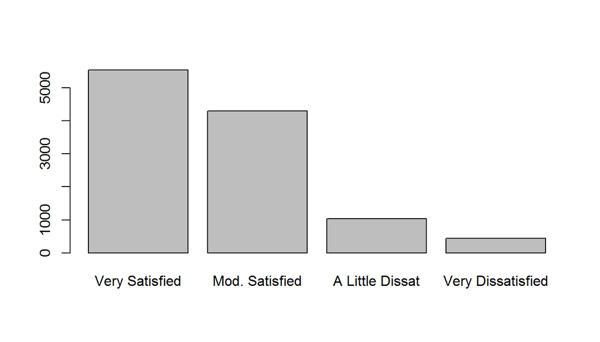

```r
barplot(table(gss$satjob))
```

The output suggests that most people are satisfied with their jobs :) But this might not be true, because the function table() automatically filters missing values. One possible situation could be that most people are just indifferent about their jobs, they are not sure if they are satisfied.

Just out of curiosity, I’m wondering if people with a higher degree tend to be more satisfied with the job.

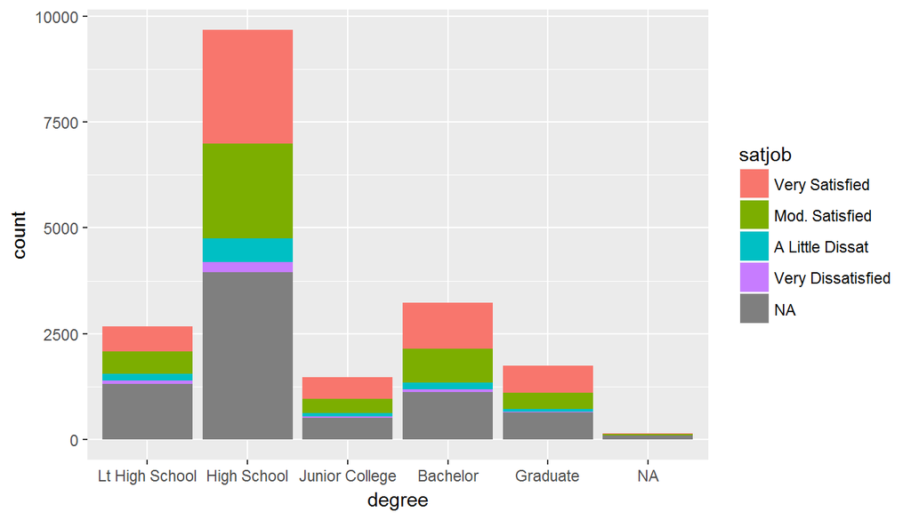

```r
ggplot(data = gss, aes(x = degree, fill = satjob)) +
  geom_bar()
```

The segment barplot shows a relatively balanced level of job satisfaction within each bar, it looks like that education level has nothing to do with job satisfaction.

Is there a relationship between age and family income? Do older people in general have more family income than younger people?

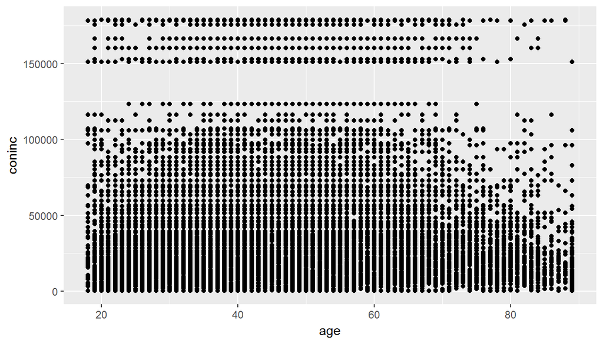

```r
ggplot(data = gss, aes(x = age, y = coninc)) +
  geom_point()
```

```r
cor(gss$age, gss$coninc, use = "complete.obs")
```

```
## [1] 0.003461516
```

In the scatterplot, we see that there are points all over the graph, which suggests that age and income are not correlated. The 0.0034615 also returns a very small correlation coefficient of 0.0035, so the two variables should be considered independent.

Is there a relationship between education level and family income? Do people with higher degrees in general have more family income?

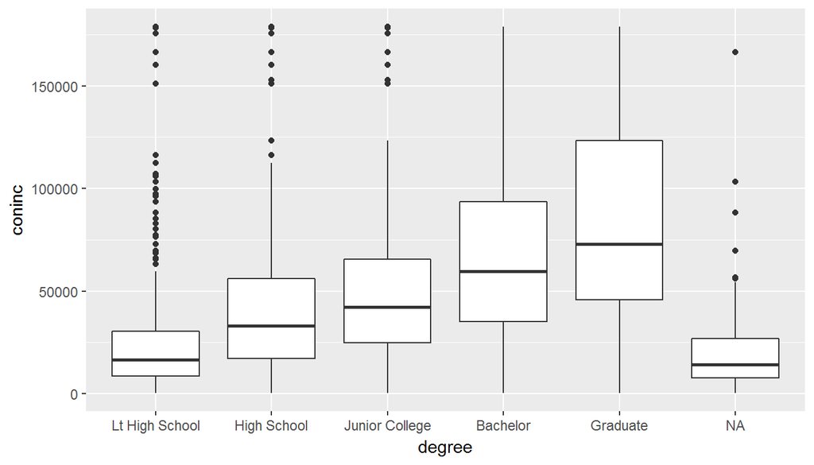

```r
ggplot(gss, aes(x = degree, y = coninc)) + geom_boxplot()
```

The side-by-side boxplot clearly shows a positive relationship between education degrees and income. As the level of education goes up, the mean and median of income also increases. There are much more outliers among people with lower degrees, which might indicate that hard work can compensate for the lack of education and finally leads to a high level of income. In addition, the distribution within each degree level is somewhat right skewed, and the IQR range becomes wider in higher degree level.

What’s the average age of respondents? What does the distribution look like? Are the survey respondents normally distributed among all ages?

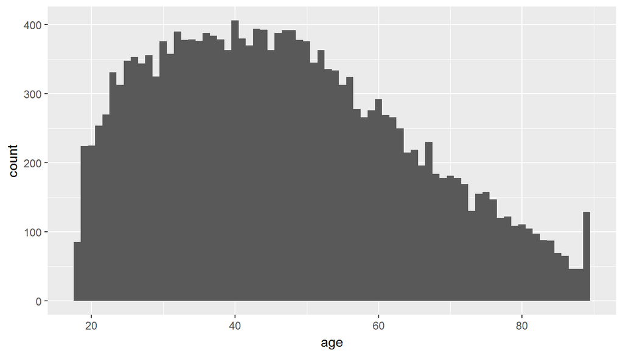

```r
gss %>%
  filter(!is.na(age)) %>%
  ggplot(aes(x = age)) +
  geom_histogram(binwidth = 1)
```

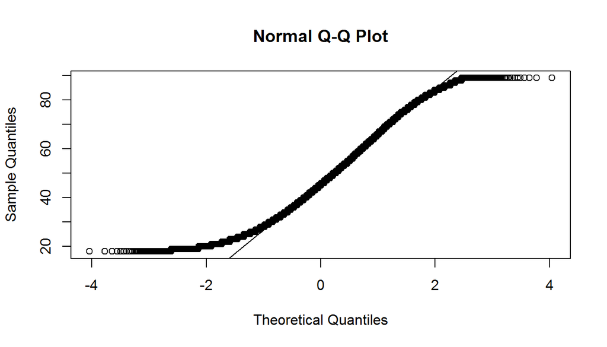

```r
qqnorm(gss$age)
qqline(gss$age)
```

Now, let’s see whether the data shows evidence that the labor market is improving every year. Concretely, if a market was improving, we would expect to see the average household income increases over time, and the increment should be no less than the average inflation rate.

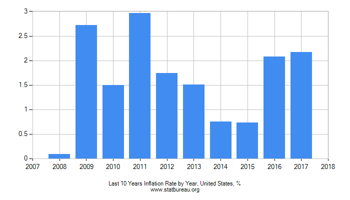

source: https://www.statbureau.org

For simplicity, we will ignore the pit in 2008 when financial crisis broke out and just assume that the average inflation rate to be around 2 percents.

First create a new variable in the dataframe called “income”. This column fills missing values with the median of “coninc” which is more robust than the mean against outliers. Filling in missing values could introduce additional biases, but the median is our best guess here. If we simply remove the observations with missing values, the remaining subset is also biased.

```r
median_coninc <- median(gss$coninc, na.rm = TRUE)
gss <- gss %>% mutate(income = ifelse(is.na(coninc), median_coninc, coninc))
sum(is.na(gss$income))
```

```
## [1] 0
```

Now that the new column does not contain missing values, next we calculate the average income in each year.

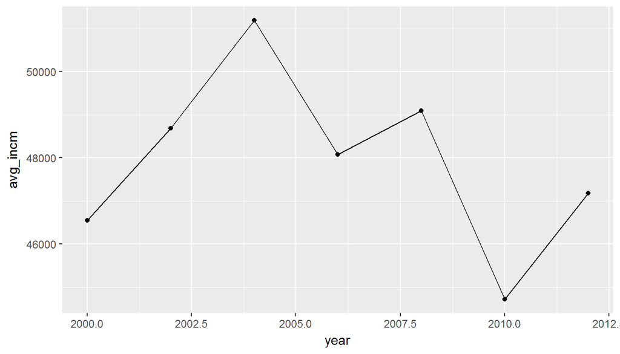

```r
gss %>%
  group_by(year) %>%
  summarise(avg_incm = mean(income)) %>%
  arrange(desc(avg_incm)) %>%
  ggplot(aes(x = year, y = avg_incm)) + geom_line() + geom_point()
```

Unfortunately, the graph shows that the average income is fluctuating with the economy around $48,000. The average income peaks in 2004, and it drops significantly right after the 2008 financial crisis.

Finally, let’s look at the proportion of people who had been unemployed for more than a month, excluding missing values.

```r
gss %>%
  filter(!is.na(unemp)) %>%
  group_by(sex) %>%
  summarise(unemp_rate = sum(unemp == "Yes") / n()) %>%
  arrange(desc(unemp_rate))
```

```
## # A tibble: 2 x 2
##   sex    unemp_rate
##   <fct>       <dbl>
## 1 Male        0.346
## 2 Female      0.321
```

The unemployment rates of males and females are close, it looks like there is no gender discrimination in terms of unemployment.

## Part 4: Inference

##### Question 1: Does it worth the money to study in a university and earn a better degree?

In the EDA part, we have observed that the average income tends to increase as the degree level goes up. Let’s test if this is true.

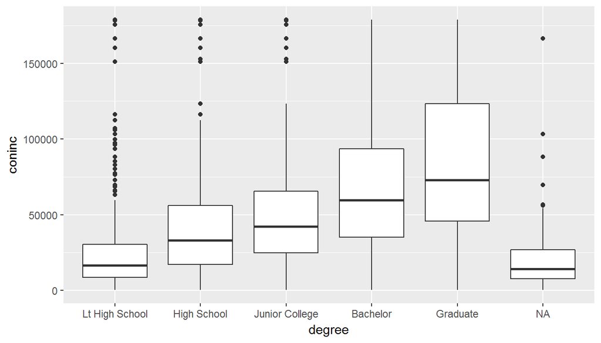

Since we are comparing means of 3+ groups, the ANOVA test and F-statistic should be used.

1. $H_0: \mu_{lths} = \mu_{hs} = \mu_{junior} = \mu_{bachelor} = \mu_{graduate}$
2. $H_A$: At least one pair of means are different from each other

```r
anova(lm(coninc ~ degree, data = gss))
```

```
## Analysis of Variance Table
##
## Response: coninc
##              Df     Sum Sq    Mean Sq F value    Pr(>F)
## degree        4 5.4142e+12 1.3535e+12  887.86 < 2.2e-16 ***
## Residuals 16505 2.5162e+13 1.5245e+09
## ---
## Signif. codes:  0 '***' 0.001 '**' 0.01 '*' 0.05 '.' 0.1 ' ' 1
```

The anova outputs a p-value very close to zero, at first glance, the data provides convincing evidence to reject the null hypothesis.

However, let’s check the conditions for ANOVA:

- Independence:
  - within groups: sample is random, count is less than 10% of that group population
  - between groups: respondents in each degree level are independent of each other (non-paired)
- Approximate normality: within each group, distributions are nearly normal?

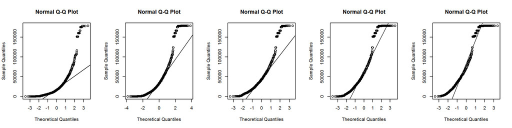

```r
par(mfrow = c(1, 5))
for (deg in levels(gss$degree)) {
  qqnorm(filter(gss, degree == deg)$coninc)
  qqline(filter(gss, degree == deg)$coninc)
  }
```

Unfortunately, it seems that distributions within each group cannot be assumed normal.

- Equal variance: groups should have roughly equal variability

```r
gss %>%
  filter(!is.na(degree) & !is.na(coninc)) %>%
  group_by(degree) %>%
  summarise(count = n(), mean = mean(coninc), sd = sd(coninc))
```

```
## # A tibble: 5 x 4
##   degree         count  mean    sd
##   <fct>          <int> <dbl> <dbl>
## 1 Lt High School  2189 23807 24897
## 2 High School     8512 41965 35571
## 3 Junior College  1304 51877 38325
## 4 Bachelor        2915 71092 48514
## 5 Graduate        1590 86017 51804
```

The variability is not consistent across groups.

In conclusion, we see that the average income is positively related with degree level, but the conditions for ANOVA failed because there’s a great diversity between groups and the income data has many outliers, the distribution within each group is also right skewed and is not normally distributed. The graph shows evidence that the median income increases as degree level goes up, however, the mean in our case is not robust due to outliers.

Just look at the median, I still believe that in most cases it’s worthwhile to pay for a higher degree. Since the distribution within group is sparse and skewed, we cannot even effectively test the median within a group using bootstrap, it’s just garbage in and garbage out.

In order to test this hypothesis, maybe we should based our analysis on the regression model and check if the coefficient of degree is significantly greater than 0.

##### Question 2: What’s the proportion of people who have earned a master degree? Is there a gender difference?

First let’s calculate the proportion for males and females, respectively.

```r
gss %>%
  filter(!is.na(degree) & !is.na(sex)) %>%
  group_by(sex) %>%
  summarise(graduate_rate = sum(degree == "Graduate") / n(), count = n())
```

```
## # A tibble: 2 x 3
##   sex    graduate_rate count
##   <fct>          <dbl> <int>
## 1 Male          0.105   8382
## 2 Female        0.0835 10418
```

Next we check the conditions for inference for comparing two independent proportions.

- Independence:
  - within groups: random sample, n < 10% of population
  - between groups: sampled males and females are independent
- Sample size/skew: the sample size is large, and the number of successes and failures are much greater than 10.

All conditions met, so we can calculate a 95% confidence interval of the proportion difference.

```r
p_male = 0.105
n_male = 8382
p_female = 0.0835
n_female = 10418
point_estimate = p_male - p_female
z_score = 1.96
SE = sqrt(p_male*(1-p_male)/n_male + p_female*(1-p_female)/n_female)
lower = point_estimate - z_score * SE
upper = point_estimate + z_score * SE
print(paste("(", as.character(lower), ", ", as.character(upper), ")", sep = ""))
```

```
## [1] "(0.0130566875209338, 0.0299433124790662)"
```

So the 95% confidence interval is roughly (0.013, 0.030).

Using the inference() function, we expect the same result.

```r
gss <- gss %>%
  filter(!is.na(degree) & !is.na(sex)) %>%
  mutate(is_graduate = ifelse(degree == "Graduate", TRUE, FALSE))
# source("http://bit.ly/dasi_inference")
inference(y = is_graduate, x = sex,
          data = gss, statistic = "proportion", type = "ci", method = "theoretical", success = TRUE)
```

```
## Response variable: categorical (2 levels, success: TRUE)
## Explanatory variable: categorical (2 levels)
## n_Male = 8382, p_hat_Male = 0.1049
## n_Female = 10418, p_hat_Female = 0.0835
## 95% CI (Male - Female): (0.0129 , 0.0298)
```

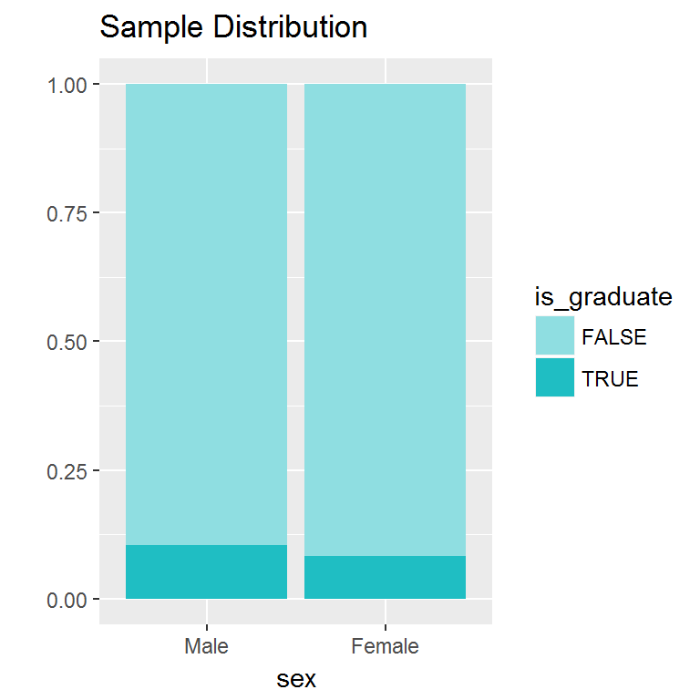

It turns out, the result is correct, so we are 95% confident that the proportion of master’s degree graduates is different bwteen males and females.

Now let’s conduct a hypothesis testing on the same question, the result should be consistent with CI. Since we have already check the conditions for inference when calculating CI, we will skip this validation step.

1. $H_0: p_{male} = p_{female}$
2. $H_A: p_{male} \ne p_{female}$

```r
inference(y = is_graduate, x = sex, data = gss, statistic = "proportion", type = "ht", null = 0,
          alternative = "twosided", method = "theoretical", success = TRUE)
```

```
## Response variable: categorical (2 levels, success: TRUE)
## Explanatory variable: categorical (2 levels)
## n_Male = 8382, p_hat_Male = 0.1049
## n_Female = 10418, p_hat_Female = 0.0835
## H0: p_Male =  p_Female
## HA: p_Male != p_Female
## z = 5.0112
## p_value = < 0.0001
```

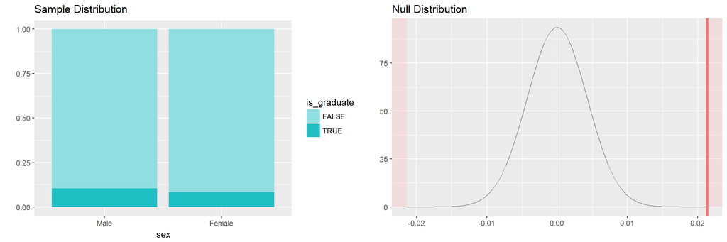

The output gives us a p-value of < 0.0001, so we reject the null hypothesis. The conclusion is the same as before, and the two methods actually agree with each other.